# **Stage 1**: Emissions – AIS Data from 2023

## **Product 1**: Create accurate table of AIS data that visited GLBA with specs

### Generate CLAA-format table of each visit to Glacier Bay in itinerary style

```python
glba_cruises = data
```

```python
#define helper function - workflow
def getCLAAFormat_inGLBA(cruiseData):
    cruise_data.assignPorts()
    cruise_data.assignBoatName()
    sub = cruise_data.gdf[cruise_data.gdf.geometry.intersects(BoatData.GLBA_BOUNDARY.union_all())] # only AIS points that intersect glba boundary

    last_index_in_glba = sub.index[-1]
    first_index_in_glba = sub.index[0]

    glba_depart = sub.iloc[-1].bs_ts # timestamp leaving GLBA for destination

    next_port, first_index_in_next_port = cruise_data.getNextPort(last_index_in_glba)
    previous_port, last_index_in_previous_port = cruise_data.getPreviousPort(first_index_in_glba)

    timelapse_to_next_port = PathCalculations.timelapseAlongPath(cruise_data.gdf.bs_ts, last_index_in_glba, first_index_in_next_port)
    _, distance_to_next_port = PathCalculations.distanceAlongPath_nm(cruise_data.gdf.geometry, last_index_in_glba, first_index_in_next_port)

    timelapse_from_previous_port = PathCalculations.timelapseAlongPath(cruise_data.gdf.bs_ts, last_index_in_previous_port, first_index_in_glba)
    _, distance_from_previous_port = PathCalculations.distanceAlongPath_nm(cruise_data.gdf.geometry, last_index_in_previous_port, first_index_in_glba)

    new_row = {'date' : list(set(sub.bs_ts.dt.date)), # should be length 1, otherwise theres an issue
                'cruiseID': cruise_data.cruiseID,
                'boatName': cruise_data.boatName,

                'portName': 'Glacier Bay',
                'ts_in': sub.bs_ts.iloc[0],
                'ts_out': sub.bs_ts.iloc[-1],

                'fromPort': previous_port,
                'fromDist': distance_from_previous_port,
                'fromTime': timelapse_from_previous_port,

                'toPort': next_port,
                'toDist': distance_to_next_port,
                'toTime': timelapse_to_next_port,
            }

    return new_row, first_index_in_glba, last_index_in_glba, first_index_in_next_port
```

```python
# populate output data tables

glba_ais_data = pd.DataFrame()
glba_claa_format = pd.DataFrame()

for cruise_id, cruise_data in glba_cruises.items():
    ### MAIN WORKFLOW ###
    new_row, first_index_in_glba, last_index_in_glba, first_index_in_next_port = getCLAAFormat_inGLBA(cruise_data)
    #cruise_data_claa = cruise_data.getCLAAFormat() # Thin data to only have one point per listing on the itinerary calendar instead of AIS format
    selected_data = cruise_data.gdf.loc[last_index_in_glba:first_index_in_next_port].copy()
    selected_data.loc[:, 'cruiseID'] = cruise_id
    glba_ais_data = pd.concat([glba_ais_data, selected_data], ignore_index=True) # exports the data between leaving GLBA and mooring at next port
    ######
    glba_claa_format = pd.concat([glba_claa_format, pd.DataFrame([new_row])], ignore_index=True)
```

Now that the two main products are produced, we can assess their accuracies but continue scripting additional funtions with the placeholder variables

Take a look at the two tables to get a grasp on the formats

```python
glba_ais_data
```

|  | lat | lon | time | bs_ts | mmsi | callsign | imo | name | nav_status | cog | ... | shiptype | draught | length | width | geometry | port | status | next_port | filled_port | cruiseID |
| --- | --- | --- | --- | --- | --- | --- | --- | --- | --- | --- | --- | --- | --- | --- | --- | --- | --- | --- | --- | --- | --- |
| 0 | 58.409908 | -135.975018 | NaN | 2023-04-19 14:42:34-08:00 | 311000710.0 | C6DL4 | 9751509.0 | NORWEGIAN BLISS | Under way using engine | 167.5 | ... | Passenger ship | 8.5 | 334.0 | 45.0 | POINT (-135.97502 58.40991) | None | inTransit | toKetchikan | Ketchikan | NORWEGIAN BLISS_01 |
| 1 | 58.407595 | -135.974055 | NaN | 2023-04-19 14:43:14-08:00 | 311000710.0 | C6DL4 | 9751509.0 | NORWEGIAN BLISS | Under way using engine | 167.7 | ... | Passenger ship | 8.5 | 334.0 | 45.0 | POINT (-135.97406 58.4076) | None | inTransit | toKetchikan | Ketchikan | NORWEGIAN BLISS_01 |
| 2 | 58.404582 | -135.972767 | NaN | 2023-04-19 14:44:04-08:00 | 311000710.0 | C6DL4 | 9751509.0 | NORWEGIAN BLISS | Under way using engine | 167.5 | ... | Passenger ship | 8.5 | 334.0 | 45.0 | POINT (-135.97277 58.40458) | None | inTransit | toKetchikan | Ketchikan | NORWEGIAN BLISS_01 |
| 3 | 58.401545 | -135.971478 | NaN | 2023-04-19 14:44:52-08:00 | 311000710.0 | C6DL4 | 9751509.0 | NORWEGIAN BLISS | Under way using engine | 167.7 | ... | Passenger ship | 8.5 | 334.0 | 45.0 | POINT (-135.97148 58.40154) | None | inTransit | toKetchikan | Ketchikan | NORWEGIAN BLISS_01 |
| 4 | 58.396450 | -135.969497 | NaN | 2023-04-19 14:46:10-08:00 | 311000710.0 | C6DL4 | 9751509.0 | NORWEGIAN BLISS | Under way using engine | 168.6 | ... | Passenger ship | 8.5 | 334.0 | 45.0 | POINT (-135.9695 58.39645) | None | inTransit | toKetchikan | Ketchikan | NORWEGIAN BLISS_01 |
| ... | ... | ... | ... | ... | ... | ... | ... | ... | ... | ... | ... | ... | ... | ... | ... | ... | ... | ... | ... | ... | ... |
| 77131 | 61.123767 | -146.362967 | NaN | 2023-09-23 06:47:59-08:00 | 257034130.0 | LAYQ7 | 9796250.0 | VIKING ORION | Under way using engine | 48.5 | ... | Passenger ship | 6.8 | 228.0 | 34.0 | POINT (-146.36297 61.12377) | None | inTransit | toValdez | Valdez | VIKING ORION_16 |
| 77132 | 61.123783 | -146.362933 | NaN | 2023-09-23 06:48:10-08:00 | 257034130.0 | LAYQ7 | 9796250.0 | VIKING ORION | Under way using engine | 60.3 | ... | Passenger ship | 6.8 | 228.0 | 34.0 | POINT (-146.36293 61.12378) | None | inTransit | toValdez | Valdez | VIKING ORION_16 |
| 77133 | 61.123800 | -146.362900 | NaN | 2023-09-23 06:48:19-08:00 | 257034130.0 | LAYQ7 | 9796250.0 | VIKING ORION | Under way using engine | 49.7 | ... | Passenger ship | 6.8 | 228.0 | 34.0 | POINT (-146.3629 61.1238) | None | inTransit | toValdez | Valdez | VIKING ORION_16 |
| 77134 | 61.123833 | -146.362833 | NaN | 2023-09-23 06:48:39-08:00 | 257034130.0 | LAYQ7 | 9796250.0 | VIKING ORION | Under way using engine | 36.3 | ... | Passenger ship | 6.8 | 228.0 | 34.0 | POINT (-146.36283 61.12383) | None | inTransit | toValdez | Valdez | VIKING ORION_16 |
| 77135 | 61.123950 | -146.362633 | NaN | 2023-09-23 06:54:35-08:00 | 257034130.0 | LAYQ7 | 9796250.0 | VIKING ORION | Moored | 183.7 | ... | Passenger ship | 6.8 | 228.0 | 34.0 | POINT (-146.36263 61.12395) | Valdez | inPort | Valdez | Valdez | VIKING ORION_16 |

77136 rows × 23 columns

```python
glba_claa_format
```

|  | date | cruiseID | boatName | portName | ts_in | ts_out | fromPort | fromDist | fromTime | toPort | toDist | toTime |
| --- | --- | --- | --- | --- | --- | --- | --- | --- | --- | --- | --- | --- |
| 0 | [2023-04-19] | NORWEGIAN BLISS_01 | NORWEGIAN BLISS | Glacier Bay | 2023-04-19 05:59:08-08:00 | 2023-04-19 14:42:34-08:00 | Skagway | 115.85 | 10.23 | Ketchikan | 298.49 | 16.05 |
| 1 | [2023-04-26] | NORWEGIAN BLISS_02 | NORWEGIAN BLISS | Glacier Bay | 2023-04-26 05:57:58-08:00 | 2023-04-26 15:08:20-08:00 | Skagway | 115.56 | 10.21 | Ketchikan | 299.19 | 15.70 |
| 2 | [2023-05-03] | NORWEGIAN BLISS_03 | NORWEGIAN BLISS | Glacier Bay | 2023-05-03 05:59:27-08:00 | 2023-05-03 15:00:23-08:00 | Skagway | 116.83 | 10.44 | Ketchikan | 300.04 | 15.80 |
| 3 | [2023-10-04] | NORWEGIAN BLISS_27 | NORWEGIAN BLISS | Glacier Bay | 2023-10-04 07:15:45-08:00 | 2023-10-04 15:33:58-08:00 | Skagway | 115.51 | 11.57 | Ketchikan | 300.82 | 14.72 |
| 4 | [2023-10-11] | NORWEGIAN BLISS_28 | NORWEGIAN BLISS | Glacier Bay | 2023-10-11 07:31:01-08:00 | 2023-10-11 15:21:39-08:00 | Skagway | 115.60 | 11.82 | Ketchikan | 299.09 | 15.14 |
| ... | ... | ... | ... | ... | ... | ... | ... | ... | ... | ... | ... | ... |
| 159 | [2023-09-23] | SEABOURN ODYSSEY_12 | SEABOURN ODYSSEY | Glacier Bay | 2023-09-23 06:53:54-08:00 | 2023-09-23 17:16:42-08:00 | Sitka | 138.96 | 13.92 | Icy Strait Point | 160.06 | 22.32 |
| 160 | [2023-10-07] | SEABOURN ODYSSEY_13 | SEABOURN ODYSSEY | Glacier Bay | 2023-10-07 07:26:44-08:00 | 2023-10-07 17:03:31-08:00 | Juneau | 91.14 | 10.30 | Wrangell | 248.67 | 15.71 |
| 161 | [2023-05-16] | VIKING ORION_02 | VIKING ORION | Glacier Bay | 2023-05-16 09:03:08-08:00 | 2023-05-16 19:10:39-08:00 | Seward | 661.27 | 15.27 | Sitka | 143.10 | 12.39 |
| 162 | [2023-09-11, 2023-09-03] | VIKING ORION_14 | VIKING ORION | Glacier Bay | 2023-09-03 06:30:23-08:00 | 2023-09-11 16:31:00-08:00 | Juneau | 91.85 | 10.15 | Haines | 139.64 | 13.52 |
| 163 | [2023-09-21] | VIKING ORION_16 | VIKING ORION | Glacier Bay | 2023-09-21 07:07:48-08:00 | 2023-09-21 17:00:37-08:00 | Ketchikan | 372.03 | 13.84 | Valdez | 516.26 | 13.90 |

164 rows × 12 columns

### Clean the data we are improperly sorting and assess accuracy

Edits required on backend

```python
# Create a boolean mask where the length of the list in 'date' column is greater than 1
mask = glba_claa_format['date'].apply(lambda x: len(x) > 1)

# Filter the DataFrame using this mask
filtered_data = glba_claa_format[mask]
cleaned_data = glba_claa_format[~mask]

total_cruise_visits = len(cleaned_data) + len(filtered_data)*2
```

```python
print(f'Total number of cruise visits to GLBA: {total_cruise_visits}') # add number of missing accurate entries
glba_ais_data.to_csv('./products/2023_ais_data_glba_cruise_visits.csv', index=False)
```

```
Total number of cruise visits to GLBA: 193
```

## **Product 2**: Compare 2023 AIS to 2023 CLAA Calendar

- Include in the above table the same data (when applicable) from the 2023 CLAA PDF. E.g., one column will have departure time from the AIS data (cross the line 3 nm from mouth of Glacier Bay) and another column will have departure time listed in the PDF. Same with next port of call, etc. Just to see how accurate the PDF is (generated prior to season) vs. what actually happened in 2023.

### Read and filter data

#### Start with historical CLAA calendars, then subset to 2023 cruises visiting GLBA

```python
claa_df = pd.read_csv('./calendar/allyears_allports_claa.csv')
claa_df['year'] = pd.to_datetime(claa_df['date']).dt.year
claa_df_2023 = claa_df[claa_df['year'] == 2023]
claa_df_2023 = claa_df_2023[['date','year','boatName','portName','nextPort','ts_in','ts_out']]
claa_df_2023_glba = claa_df_2023[claa_df_2023['portName'] == 'GLACIER BAY']
claa_df_2023_glba # CLAA import for 2023 scheduled itineraries
```

|  | date | year | boatName | portName | nextPort | ts_in | ts_out |
| --- | --- | --- | --- | --- | --- | --- | --- |
| 37233 | 2023-07-09 | 2023 | CROWN PRINCESS | GLACIER BAY | ICY STRAIT POINT | 2023-07-09 06:00:00 | 2023-07-09 15:00:00 |
| 37751 | 2023-05-02 | 2023 | EURODAM | GLACIER BAY | ICY STRAIT POINT | 2023-05-02 07:00:00 | 2023-05-02 16:00:00 |
| 37759 | 2023-05-09 | 2023 | EURODAM | GLACIER BAY | ICY STRAIT POINT | 2023-05-09 07:00:00 | 2023-05-09 16:00:00 |
| 37767 | 2023-05-16 | 2023 | EURODAM | GLACIER BAY | ICY STRAIT POINT | 2023-05-16 07:00:00 | 2023-05-16 16:00:00 |
| 37775 | 2023-05-23 | 2023 | EURODAM | GLACIER BAY | ICY STRAIT POINT | 2023-05-23 07:00:00 | 2023-05-23 16:00:00 |
| ... | ... | ... | ... | ... | ... | ... | ... |
| 43090 | 2023-08-27 | 2023 | VOLENDAM | GLACIER BAY | KETCHIKAN | 2023-08-27 07:00:00 | 2023-08-27 16:00:00 |
| 43098 | 2023-09-03 | 2023 | VOLENDAM | GLACIER BAY | KETCHIKAN | 2023-09-03 07:00:00 | 2023-09-03 16:00:00 |
| 43106 | 2023-09-10 | 2023 | VOLENDAM | GLACIER BAY | KETCHIKAN | 2023-09-10 07:00:00 | 2023-09-10 16:00:00 |
| 43114 | 2023-09-17 | 2023 | VOLENDAM | GLACIER BAY | KETCHIKAN | 2023-09-17 07:00:00 | 2023-09-17 16:00:00 |
| 43122 | 2023-09-24 | 2023 | VOLENDAM | GLACIER BAY | KETCHIKAN | 2023-09-24 07:00:00 | 2023-09-24 16:00:00 |

254 rows × 7 columns

#### Filter the CLAA-format 2023 AIS data visiting GLBA to only "proper" entries (date of length one meaning correct cruise sorting)

```python
mask = glba_claa_format['date'].apply(lambda x: len(x) == 1) # filtering to data with one date right now (accurate)

# Filter the DataFrame using this mask
filtered_data = glba_claa_format[mask]
filtered_data['date'] = filtered_data['date'].apply(lambda x: x[0])

filtered_data
```

|  | date | cruiseID | boatName | portName | ts_in | ts_out | fromPort | fromDist | fromTime | toPort | toDist | toTime |
| --- | --- | --- | --- | --- | --- | --- | --- | --- | --- | --- | --- | --- |
| 0 | 2023-04-19 | NORWEGIAN BLISS_01 | NORWEGIAN BLISS | Glacier Bay | 2023-04-19 05:59:08-08:00 | 2023-04-19 14:42:34-08:00 | Skagway | 115.85 | 10.23 | Ketchikan | 298.49 | 16.05 |
| 1 | 2023-04-26 | NORWEGIAN BLISS_02 | NORWEGIAN BLISS | Glacier Bay | 2023-04-26 05:57:58-08:00 | 2023-04-26 15:08:20-08:00 | Skagway | 115.56 | 10.21 | Ketchikan | 299.19 | 15.70 |
| 2 | 2023-05-03 | NORWEGIAN BLISS_03 | NORWEGIAN BLISS | Glacier Bay | 2023-05-03 05:59:27-08:00 | 2023-05-03 15:00:23-08:00 | Skagway | 116.83 | 10.44 | Ketchikan | 300.04 | 15.80 |
| 3 | 2023-10-04 | NORWEGIAN BLISS_27 | NORWEGIAN BLISS | Glacier Bay | 2023-10-04 07:15:45-08:00 | 2023-10-04 15:33:58-08:00 | Skagway | 115.51 | 11.57 | Ketchikan | 300.82 | 14.72 |
| 4 | 2023-10-11 | NORWEGIAN BLISS_28 | NORWEGIAN BLISS | Glacier Bay | 2023-10-11 07:31:01-08:00 | 2023-10-11 15:21:39-08:00 | Skagway | 115.60 | 11.82 | Ketchikan | 299.09 | 15.14 |
| ... | ... | ... | ... | ... | ... | ... | ... | ... | ... | ... | ... | ... |
| 158 | 2023-09-02 | SEABOURN ODYSSEY_10 | SEABOURN ODYSSEY | Glacier Bay | 2023-09-02 06:56:01-08:00 | 2023-09-02 16:55:53-08:00 | Juneau | 91.42 | 9.67 | Wrangell | 247.07 | 16.22 |
| 159 | 2023-09-23 | SEABOURN ODYSSEY_12 | SEABOURN ODYSSEY | Glacier Bay | 2023-09-23 06:53:54-08:00 | 2023-09-23 17:16:42-08:00 | Sitka | 138.96 | 13.92 | Icy Strait Point | 160.06 | 22.32 |
| 160 | 2023-10-07 | SEABOURN ODYSSEY_13 | SEABOURN ODYSSEY | Glacier Bay | 2023-10-07 07:26:44-08:00 | 2023-10-07 17:03:31-08:00 | Juneau | 91.14 | 10.30 | Wrangell | 248.67 | 15.71 |
| 161 | 2023-05-16 | VIKING ORION_02 | VIKING ORION | Glacier Bay | 2023-05-16 09:03:08-08:00 | 2023-05-16 19:10:39-08:00 | Seward | 661.27 | 15.27 | Sitka | 143.10 | 12.39 |
| 163 | 2023-09-21 | VIKING ORION_16 | VIKING ORION | Glacier Bay | 2023-09-21 07:07:48-08:00 | 2023-09-21 17:00:37-08:00 | Ketchikan | 372.03 | 13.84 | Valdez | 516.26 | 13.90 |

135 rows × 12 columns

### Compare 2023 AIS data to CLAA calendar by boatName

```python
filtered_data.boatName.value_counts() # 2023 AIS data that visited GLBA
```

```
NORWEGIAN ENCORE    25
EURODAM             22
KONINGSDAM          22
VOLENDAM            20
NORWEGIAN JEWEL     11
NORWEGIAN SUN        8
NORWEGIAN BLISS      7
RUBY PRINCESS        7
SEABOURN ODYSSEY     4
NIEUW AMSTERDAM      3
NORWEGIAN SPIRIT     2
VIKING ORION         2
CROWN PRINCESS       1
NOORDAM              1
Name: boatName, dtype: int64
```

```python
claa_df_2023_glba.boatName.value_counts() # 2023 CLAA Itinerary Calendar value counts
```

```
NORWEGIAN ENCORE     25
KONINGSDAM           22
EURODAM              22
NIEUW AMSTERDAM      21
VOLENDAM             20
ROYAL PRINCESS       20
GRAND PRINCESS       20
SAPPHIRE PRINCESS    20
MAJESTIC PRINCESS    19
NOORDAM              19
NORWEGIAN JEWEL      11
NORWEGIAN BLISS       7
NORWEGIAN SUN         6
QUEEN ELIZABETH       6
RUBY PRINCESS         5
SEABOURN ODYSSEY      4
VIKING ORION          4
NORWEGIAN SPIRIT      2
CROWN PRINCESS        1
Name: boatName, dtype: int64
```

### Merge 2023 AIS and 2023 CLAA data

Convert date columns to datetime type to merge and cross check AIS/CLAA dataframes

```python
filtered_data['date'] = pd.to_datetime(filtered_data['date'])
claa_df_2023_glba['date'] = pd.to_datetime(claa_df_2023_glba['date'])
```

```python
claa_2023_merged_ais = filtered_data.merge(claa_df_2023_glba,
                                              on=['boatName', 'date'], how='inner', suffixes=('_ais', '_claa'))
claa_2023_merged_ais = claa_2023_merged_ais[['date', 'cruiseID', 'boatName', 'fromPort', 'portName_ais', 'toPort', 'nextPort', 'ts_out_ais', 'ts_out_claa']]
claa_2023_merged_ais # next port from CLAA, to port from AIS
```

|  | date | cruiseID | boatName | fromPort | portName_ais | toPort | nextPort | ts_out_ais | ts_out_claa |
| --- | --- | --- | --- | --- | --- | --- | --- | --- | --- |
| 0 | 2023-04-19 | NORWEGIAN BLISS_01 | NORWEGIAN BLISS | Skagway | Glacier Bay | Ketchikan | KETCHIKAN | 2023-04-19 14:42:34-08:00 | 2023-04-19 15:00:00 |
| 1 | 2023-04-26 | NORWEGIAN BLISS_02 | NORWEGIAN BLISS | Skagway | Glacier Bay | Ketchikan | KETCHIKAN | 2023-04-26 15:08:20-08:00 | 2023-04-26 15:00:00 |
| 2 | 2023-05-03 | NORWEGIAN BLISS_03 | NORWEGIAN BLISS | Skagway | Glacier Bay | Ketchikan | KETCHIKAN | 2023-05-03 15:00:23-08:00 | 2023-05-03 15:00:00 |
| 3 | 2023-10-04 | NORWEGIAN BLISS_27 | NORWEGIAN BLISS | Skagway | Glacier Bay | Ketchikan | KETCHIKAN | 2023-10-04 15:33:58-08:00 | 2023-10-04 15:00:00 |
| 4 | 2023-10-11 | NORWEGIAN BLISS_28 | NORWEGIAN BLISS | Skagway | Glacier Bay | Ketchikan | KETCHIKAN | 2023-10-11 15:21:39-08:00 | 2023-10-11 15:00:00 |
| ... | ... | ... | ... | ... | ... | ... | ... | ... | ... |
| 124 | 2023-09-02 | SEABOURN ODYSSEY_10 | SEABOURN ODYSSEY | Juneau | Glacier Bay | Wrangell | WRANGELL | 2023-09-02 16:55:53-08:00 | 2023-09-02 15:00:00 |
| 125 | 2023-09-23 | SEABOURN ODYSSEY_12 | SEABOURN ODYSSEY | Sitka | Glacier Bay | Icy Strait Point | ICY STRAIT POINT | 2023-09-23 17:16:42-08:00 | 2023-09-23 18:00:00 |
| 126 | 2023-10-07 | SEABOURN ODYSSEY_13 | SEABOURN ODYSSEY | Juneau | Glacier Bay | Wrangell | WRANGELL | 2023-10-07 17:03:31-08:00 | 2023-10-07 15:00:00 |
| 127 | 2023-05-16 | VIKING ORION_02 | VIKING ORION | Seward | Glacier Bay | Sitka | SITKA | 2023-05-16 19:10:39-08:00 | 2023-05-16 19:00:00 |
| 128 | 2023-09-21 | VIKING ORION_16 | VIKING ORION | Ketchikan | Glacier Bay | Valdez | HUBBARD GLACIER | 2023-09-21 17:00:37-08:00 | 2023-09-21 16:00:00 |

129 rows × 9 columns

## **Product 3**: Summary statistics tables for each port after Glacier Bay

```python
glba_ais_data

cruise_stats = glba_ais_data.groupby('cruiseID').agg({
    'sog': ['mean', 'std', 'count']#,
    #'toTime': ['mean', 'std', 'count'],
    #'toDistance': ['mean', 'std', 'count']
}).reset_index()

# Flatten the MultiIndex in columns
cruise_stats.columns = ['_'.join(col).strip() if col[1] else col[0] for col in cruise_stats.columns]

# Rename 'cruise_id_' back to 'cruise_id'
cruise_stats.rename(columns={'cruise_id_': 'cruise_id'}, inplace=True)

cruise_stats
```

|  | cruiseID | sog_mean | sog_std | sog_count |
| --- | --- | --- | --- | --- |
| 0 | CROWN PRINCESS_09 | 10.257985 | 3.175247 | 407 |
| 1 | EURODAM_01 | 11.681679 | 4.688034 | 131 |
| 2 | EURODAM_02 | 12.857692 | 5.285579 | 130 |
| 3 | EURODAM_03 | 13.672483 | 4.614883 | 149 |
| 4 | EURODAM_04 | 12.680916 | 5.454329 | 131 |
| ... | ... | ... | ... | ... |
| 159 | VOLENDAM_19 | 14.694485 | 3.603028 | 544 |
| 160 | VOLENDAM_20 | 14.674245 | 3.565058 | 563 |
| 161 | VOLENDAM_21 | 13.663167 | 4.635934 | 600 |
| 162 | VOLENDAM_22 | 15.696530 | 3.596526 | 634 |
| 163 | VOLENDAM_24 | 16.556107 | 4.238562 | 524 |

164 rows × 4 columns

```python
glba_claa_2023_merged_stats = glba_claa_format.merge(cruise_stats[['cruiseID', 'sog_mean', 'sog_std']], #append additional attributes here
                                   on='cruiseID', how='left')
glba_claa_2023_merged_stats # print out CLAA format with sog means
```

|  | date | cruiseID | boatName | portName | ts_in | ts_out | fromPort | fromDist | fromTime | toPort | toDist | toTime | sog_mean | sog_std |
| --- | --- | --- | --- | --- | --- | --- | --- | --- | --- | --- | --- | --- | --- | --- |
| 0 | [2023-04-19] | NORWEGIAN BLISS_01 | NORWEGIAN BLISS | Glacier Bay | 2023-04-19 05:59:08-08:00 | 2023-04-19 14:42:34-08:00 | Skagway | 115.85 | 10.23 | Ketchikan | 298.49 | 16.05 | 16.386523 | 5.762748 |
| 1 | [2023-04-26] | NORWEGIAN BLISS_02 | NORWEGIAN BLISS | Glacier Bay | 2023-04-26 05:57:58-08:00 | 2023-04-26 15:08:20-08:00 | Skagway | 115.56 | 10.21 | Ketchikan | 299.19 | 15.70 | 17.311364 | 5.391468 |
| 2 | [2023-05-03] | NORWEGIAN BLISS_03 | NORWEGIAN BLISS | Glacier Bay | 2023-05-03 05:59:27-08:00 | 2023-05-03 15:00:23-08:00 | Skagway | 116.83 | 10.44 | Ketchikan | 300.04 | 15.80 | 17.337827 | 5.010294 |
| 3 | [2023-10-04] | NORWEGIAN BLISS_27 | NORWEGIAN BLISS | Glacier Bay | 2023-10-04 07:15:45-08:00 | 2023-10-04 15:33:58-08:00 | Skagway | 115.51 | 11.57 | Ketchikan | 300.82 | 14.72 | 18.475577 | 5.785464 |
| 4 | [2023-10-11] | NORWEGIAN BLISS_28 | NORWEGIAN BLISS | Glacier Bay | 2023-10-11 07:31:01-08:00 | 2023-10-11 15:21:39-08:00 | Skagway | 115.60 | 11.82 | Ketchikan | 299.09 | 15.14 | 17.678598 | 5.625991 |
| ... | ... | ... | ... | ... | ... | ... | ... | ... | ... | ... | ... | ... | ... | ... |
| 159 | [2023-09-23] | SEABOURN ODYSSEY_12 | SEABOURN ODYSSEY | Glacier Bay | 2023-09-23 06:53:54-08:00 | 2023-09-23 17:16:42-08:00 | Sitka | 138.96 | 13.92 | Icy Strait Point | 160.06 | 22.32 | 8.422292 | 3.562008 |
| 160 | [2023-10-07] | SEABOURN ODYSSEY_13 | SEABOURN ODYSSEY | Glacier Bay | 2023-10-07 07:26:44-08:00 | 2023-10-07 17:03:31-08:00 | Juneau | 91.14 | 10.30 | Wrangell | 248.67 | 15.71 | 15.390000 | 1.883809 |
| 161 | [2023-05-16] | VIKING ORION_02 | VIKING ORION | Glacier Bay | 2023-05-16 09:03:08-08:00 | 2023-05-16 19:10:39-08:00 | Seward | 661.27 | 15.27 | Sitka | 143.10 | 12.39 | 10.928770 | 2.507782 |
| 162 | [2023-09-11, 2023-09-03] | VIKING ORION_14 | VIKING ORION | Glacier Bay | 2023-09-03 06:30:23-08:00 | 2023-09-11 16:31:00-08:00 | Juneau | 91.85 | 10.15 | Haines | 139.64 | 13.52 | 9.565445 | 2.719196 |
| 163 | [2023-09-21] | VIKING ORION_16 | VIKING ORION | Glacier Bay | 2023-09-21 07:07:48-08:00 | 2023-09-21 17:00:37-08:00 | Ketchikan | 372.03 | 13.84 | Valdez | 516.26 | 13.90 | 13.259442 | 4.041278 |

164 rows × 14 columns

- From the above dataframe, I (or you) can then generate a summary table by port (Table with each next port of call constituting the number of rows, e.g., Skagaway, Ketchikan, Ward Cove, etc.) with summary stats of each (N, mean, StdDev) applicable measure (avg speed over ground SOG, avg time to next port, etc.). For Next port of call, this will help address how much variation is there in routes and their distances. For example, if ships going to SKG, how many go direct vs. going out to Gulf to do a loop and dump wastewater. Likewise, some ships may take multiple routes to Ketchikan including those that go down Chatham Strait vs. those that go out into the Gulf then come back in.

```python
claa_format_stats = glba_claa_2023_merged_stats.groupby('toPort').agg({
    'sog_mean': ['mean', 'std', 'count'],
    'toTime' : ['mean', 'std', 'count'],
    'toDist' : ['mean', 'std', 'count']
    #'toTime': ['mean', 'std', 'count'],
    #'toDistance': ['mean', 'std', 'count']
}).reset_index()

# Flatten the MultiIndex in columns
claa_format_stats.columns = ['_'.join(col).strip() if col[1] else col[0] for col in claa_format_stats.columns]

# Rename 'cruise_id_' back to 'cruise_id'
claa_format_stats.rename(columns={'toPort_': 'toPort'}, inplace=True)

claa_format_stats
```

|  | toPort | sog_mean_mean | sog_mean_std | sog_mean_count | toTime_mean | toTime_std | toTime_count | toDist_mean | toDist_std | toDist_count |
| --- | --- | --- | --- | --- | --- | --- | --- | --- | --- | --- |
| 0 | EndOfCruise | 13.447270 | NaN | 1 | 8.830000 | NaN | 1 | 390.480000 | NaN | 1 |
| 1 | Haines | 9.565445 | NaN | 1 | 13.520000 | NaN | 1 | 139.640000 | NaN | 1 |
| 2 | Icy Strait Point | 12.282035 | 1.643155 | 27 | 4.448148 | 5.834548 | 27 | 46.207037 | 44.704715 | 27 |
| 3 | Juneau | 12.486332 | 2.894532 | 3 | 13.800000 | 0.630238 | 3 | 180.100000 | 41.675177 | 3 |
| 4 | Ketchikan | 16.273846 | 1.350539 | 80 | 17.351125 | 2.059882 | 80 | 302.431000 | 5.507953 | 80 |
| 5 | Prince Rupert | 16.734164 | 0.320312 | 2 | 20.700000 | 0.056569 | 2 | 398.630000 | 2.941564 | 2 |
| 6 | Seward | 13.898173 | 0.320618 | 10 | 13.468000 | 0.360272 | 10 | 541.931000 | 7.875029 | 10 |
| 7 | Sitka | 10.267873 | 0.932150 | 3 | 13.806667 | 1.705706 | 3 | 140.490000 | 6.481875 | 3 |
| 8 | Skagway | 10.735540 | 1.228099 | 34 | 11.391176 | 2.206962 | 34 | 127.771765 | 36.760500 | 34 |
| 9 | Valdez | 13.259442 | NaN | 1 | 13.900000 | NaN | 1 | 516.260000 | NaN | 1 |
| 10 | Wrangell | 14.928795 | 0.652242 | 2 | 15.965000 | 0.360624 | 2 | 247.870000 | 1.131371 | 2 |

## **Product 4**: Map that visualizes typical routes between GLBA and other locations

- Take the ‘representative’ routes for each port of call (or perhaps the most common 5) and create a publishable quality map (in ArcPro) to demonstrate the ‘average’ route of ships during their ports of call following Glacier Bay. Perhaps using a grid overlain on the domain, demonstrate the speed and route to the next port of call. This demonstrates the actual (empirical) data, perhaps in form of a heat map?

```python
# here I will add code to do this, probably in ArcGIS pro.
```

[output not shown]

#### step 2: make management alternative maps

- For same grid and map, we’ll want to demonstrate deviation in speeds in a management alternative scenario (e.g., should ships take an extra 30min or 60 mins in Glacier Bay). What we want to show is that when a ship is going to, e.g., Skagway after Glacier Bay
  - Speed in Glacier Bay drops significantly from actual to modeled alternative
  - Speed from Glacier Bay to next port of call does not increase significantly (e.g., for Haines, Juneau, Skagway) but does increase to other ports of call (e.g., Ketchikan, Wrangell).
  - I will also get estimates of the SOX and NOX, PM and CO2 for each of these mgmnt alternatives and perhaps we could table those estimates (e.g., total fuel consumed existing vs. mgmnt alt 1, 2, total SOX emitted existing vs. mgmtn 1, 2, etc.).

# **Stage 2**: CLAA Port Call Data

## **Product 1**: Table of all ships in CLAA data since 2008 – Complete

- Create a table of all ships in CLAA database since 2008

using `CalendarParser.py`:

```python
from CalendarParser import *

folder = r'./calendar/historical_cruise_schedules'

dfs = []

for root, _, files in os.walk(folder):
    for file in files:
        if file.lower().endswith('.pdf'):
            pdf_path = os.path.join(root, file)
            print(pdf_path)
            csv_path = pdf_path.replace('pdf', 'csv')
            year = pdf_path.split('/')[-1][:4]

            parser = CalendarParser(pdf_path, csv_path, year)
            parser.processPDF()
            parser.createDailyRows()
            parser.convertCodesToNames()
            parser.fillNextPorts()
            parser.df.to_csv(parser.csv_path, index=False)
            dfs.append(parser.df)

# Concatenate all DataFrames in the list into one big DataFrame
big_df = pd.concat(dfs, ignore_index=True)

#output statistics for easy cleanup
grouped = big_df.groupby('boatName').size().reset_index(name='count')
grouped.to_csv('./calendar/allyears_allports_claa_groupstats.csv', index=False)

big_df.to_csv('./calendar/allyears_allports_claa.csv')
```

Read the results here:

```python
claa_df = pd.read_csv('./calendar/allyears_allports_claa.csv')
claa_df
```

|  | Unnamed: 0 | date | boatName | portCode | ts_in | ts_out | portName | nextPort |
| --- | --- | --- | --- | --- | --- | --- | --- | --- |
| 0 | 0 | 2010-05-03 | AMSTERDAM | SEA | 2010-05-03 07:00:00 | 2010-05-03 16:00:00 | SEATTLE | AT SEA |
| 1 | 1 | 2010-05-04 | AMSTERDAM | AS | 2010-05-04 06:00:00 | 2010-05-04 22:00:00 | AT SEA | GLACIER BAY |
| 2 | 2 | 2010-05-05 | AMSTERDAM | GB | 2010-05-05 10:00:00 | 2010-05-05 19:00:00 | GLACIER BAY | JUNEAU |
| 3 | 3 | 2010-05-06 | AMSTERDAM | JNU | 2010-05-06 07:00:00 | 2010-05-06 20:00:00 | JUNEAU | SITKA |
| 4 | 4 | 2010-05-07 | AMSTERDAM | SIT | 2010-05-07 08:00:00 | 2010-05-07 17:00:00 | SITKA | KETCHIKAN |
| ... | ... | ... | ... | ... | ... | ... | ... | ... |
| 68372 | 68372 | 2019-09-29 | WESTERDAM | VAN | 2019-09-29 07:00:00 | 2019-09-29 16:30:00 | VANCOUVER | AT SEA |
| 68373 | 68373 | 2019-09-30 | WESTERDAM | AS | 2019-09-30 06:00:00 | 2019-09-30 22:00:00 | AT SEA | JUNEAU |
| 68374 | 68374 | 2019-10-01 | WESTERDAM | JNU | 2019-10-01 13:00:00 | 2019-10-01 23:00:00 | JUNEAU | NaN |
| 68375 | 68375 | 2019-09-10 | WORLD OF RESIDENSE | NOM | 2019-09-10 09:00:00 | unknown | NOME | NOME |
| 68376 | 68376 | 2019-09-11 | WORLD OF RESIDENSE | NOM | unknown | 2019-09-11 23:00:00 | NOME | NaN |

68377 rows × 8 columns

## **Product 2**: Merged data table that attributes each ship

- Merge with data on ship attributes including size, max pax, etc. Cruise Critic, lit search, Wiki?
  - Note that CLAA may have scheduled certain ships but stopped doing so
  - Some other ships may have taken on new names
  - Some small ships also likely reduced classic port calls owing to niche for off beaten path routes and ability to visit ports unscheduled.
  - We’ll want to create a ‘floor’ representing a minimum size (GT, Max Pax, LOA) that minimizes or eliminates chance CLAA would not have them listed in their data for port scheduling (we’re focused on ‘large’ cruise ships)
  - We’ll also explore how ships in this class have increase in avg size, GT, MaxPax over the years
  - Histogram of number of unique ships in each year across years

```python
ports = claa_df[['date', 'boatName','portName']]
ports = ports[ports['portName']!= 'AT SEA']
ports
```

|  | date | boatName | portName |
| --- | --- | --- | --- |
| 0 | 2010-05-03 | AMSTERDAM | SEATTLE |
| 2 | 2010-05-05 | AMSTERDAM | GLACIER BAY |
| 3 | 2010-05-06 | AMSTERDAM | JUNEAU |
| 4 | 2010-05-07 | AMSTERDAM | SITKA |
| 5 | 2010-05-08 | AMSTERDAM | KETCHIKAN |
| ... | ... | ... | ... |
| 68370 | 2019-09-27 | WESTERDAM | KETCHIKAN |
| 68372 | 2019-09-29 | WESTERDAM | VANCOUVER |
| 68374 | 2019-10-01 | WESTERDAM | JUNEAU |
| 68375 | 2019-09-10 | WORLD OF RESIDENSE | NOME |
| 68376 | 2019-09-11 | WORLD OF RESIDENSE | NOME |

51402 rows × 3 columns

```python
print('Ports planned on CLAA between 2008 and 2023')
print()
values = ports.portName.value_counts()
for e in ports.portName.unique():
    print(f'{e} : {values[e]}')
```

```
Ports planned on CLAA between 2008 and 2023

SEATTLE : 3045
GLACIER BAY : 3238
JUNEAU : 7639
SITKA : 2420
KETCHIKAN : 6945
VICTORIA : 3157
SKAGWAY : 5645
ANCHORAGE : 90
HOMER : 97
KODIAK : 229
HUBBARD GLACIER : 2364
TRACY ARM : 3399
ASTORIA : 120
VANCOUVER : 3257
MISTY FJORD : 381
COLLEGE FJORD : 890
SEWARD : 960
NOME : 93
ST. MATHEW : 32
ST. PAUL : 45
DUTCH HARBOR : 130
ICY BAY : 40
ENDICOTT ARM : 834
PETERSBURG : 793
PRINCE RUPERT : 345
ALERT BAY : 90
KAKE : 50
ELFIN COVE : 38
ADAK : 12
ATTU : 20
LOS ANGELES : 104
WHITTIER : 612
SAN FRANCISCO : 479
POINT BARROW : 27
POINT SOPHIA : 463
SAN DIEGO : 39
NANAIMO : 38
Unknown : 90
HAINES : 731
BARTLETT COVE : 768
VALDEZ : 96
WRANGELL : 362
METLAKATLA : 107
CORDOVA : 59
ICY STRAIT POINT : 979
COLD BAY : 1
PELICAN : 6
KENAI FJORD : 41
BARONOF WARM SPRINGS : 1
GUSTAVUS : 1
```

#### Use `matplotlib` to visualize changes in port calls

```python
ports
```

|  | date | boatName | portName |
| --- | --- | --- | --- |
| 0 | 2010-05-03 | AMSTERDAM | SEATTLE |
| 2 | 2010-05-05 | AMSTERDAM | GLACIER BAY |
| 3 | 2010-05-06 | AMSTERDAM | JUNEAU |
| 4 | 2010-05-07 | AMSTERDAM | SITKA |
| 5 | 2010-05-08 | AMSTERDAM | KETCHIKAN |
| ... | ... | ... | ... |
| 68370 | 2019-09-27 | WESTERDAM | KETCHIKAN |
| 68372 | 2019-09-29 | WESTERDAM | VANCOUVER |
| 68374 | 2019-10-01 | WESTERDAM | JUNEAU |
| 68375 | 2019-09-10 | WORLD OF RESIDENSE | NOME |
| 68376 | 2019-09-11 | WORLD OF RESIDENSE | NOME |

51402 rows × 3 columns

[figure not shown]

```python
import matplotlib.pyplot as plt

df = ports

df['date'] = pd.to_datetime(df['date'])

total_counts = df['portName'].value_counts()

top_locations = total_counts.head(7).index
filtered_df = df[df['portName'].isin(top_locations)]

filtered_df.set_index('date', inplace=True)

weekly_counts = filtered_df.groupby('portName').resample('M').size().unstack(fill_value=0)

# Transpose the DataFrame to have time on the x-axis and port names on the y-axis
weekly_counts = weekly_counts.T

# Plot the change in frequency for each portName over time
weekly_counts.plot(kind='line', linestyle='-', marker='', linewidth=2)
plt.title('Change in Frequency of Top 5 Ports Visited Over Time')
plt.xlabel('Date')
plt.ylabel('Frequency')
plt.legend(title='Port Name')
plt.grid(True)
plt.xticks(rotation=45)
plt.tight_layout()
plt.show()
```

#### Adapt for other visualization

```python
claa_df.boatName.value_counts()
```

```
VOLENDAM               2073
MILLENNIUM             1853
RADIANCE OF THE SEA    1805
WESTERDAM              1725
NORWEGIAN JEWEL        1629
                       ...
LE COMMANDANT             4
NG ENDURENCE              3
OF RESIDENSE              1
LE COMMANDANT CHA         1
SKY                       1
Name: boatName, Length: 134, dtype: int64
```

```python
ships = claa_df.boatName.value_counts()
ships
```

```
VOLENDAM               2073
MILLENNIUM             1853
RADIANCE OF THE SEA    1805
WESTERDAM              1725
NORWEGIAN JEWEL        1629
                       ...
LE COMMANDANT             4
NG ENDURENCE              3
OF RESIDENSE              1
LE COMMANDANT CHA         1
SKY                       1
Name: boatName, Length: 134, dtype: int64
```

## **Product 3**: Analytics of Port Calls since 2008

```python
ships
```

```
VOLENDAM               2073
MILLENNIUM             1853
RADIANCE OF THE SEA    1805
WESTERDAM              1725
NORWEGIAN JEWEL        1629
                       ...
LE COMMANDANT             4
NG ENDURENCE              3
OF RESIDENSE              1
LE COMMANDANT CHA         1
SKY                       1
Name: boatName, Length: 134, dtype: int64
```

#### Produce histogram of change in unique port calls

- Create a table of all port calls listed since 2008
  - Histogram of number of unique ports in a year and how this varies across years
  - Create a publishable quality map showing those port calls, including ‘glacial fjords’

```python
ports['year'] = pd.to_datetime(ports['date']).dt.year
ports
```

|  | date | boatName | portName | year |
| --- | --- | --- | --- | --- |
| 0 | 2010-05-03 | AMSTERDAM | SEATTLE | 2010 |
| 2 | 2010-05-05 | AMSTERDAM | GLACIER BAY | 2010 |
| 3 | 2010-05-06 | AMSTERDAM | JUNEAU | 2010 |
| 4 | 2010-05-07 | AMSTERDAM | SITKA | 2010 |
| 5 | 2010-05-08 | AMSTERDAM | KETCHIKAN | 2010 |
| ... | ... | ... | ... | ... |
| 68370 | 2019-09-27 | WESTERDAM | KETCHIKAN | 2019 |
| 68372 | 2019-09-29 | WESTERDAM | VANCOUVER | 2019 |
| 68374 | 2019-10-01 | WESTERDAM | JUNEAU | 2019 |
| 68375 | 2019-09-10 | WORLD OF RESIDENSE | NOME | 2019 |
| 68376 | 2019-09-11 | WORLD OF RESIDENSE | NOME | 2019 |

51402 rows × 4 columns

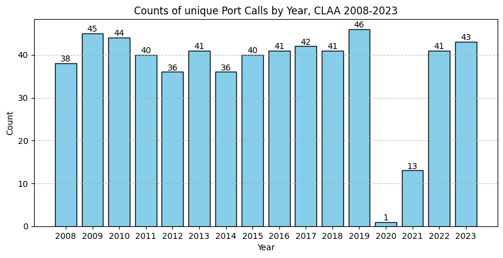

```python
portChanges = pd.DataFrame()

grouped = ports.groupby('year', dropna = True)
for year, group in grouped:
        unique_ports = len(group.portName.unique())
        new_row = {'year' : year,
                   'unique_ports' : unique_ports}
        portChanges = pd.concat([portChanges, pd.DataFrame([new_row])])

plt.figure(figsize=(10,4.5))
bars = plt.bar(portChanges['year'], portChanges['unique_ports'], color='skyblue', edgecolor='black')

plt.xlabel('Year')
plt.ylabel('Count')
plt.title('Counts of unique Port Calls by Year, CLAA 2008-2023')
plt.xticks(portChanges['year'])
plt.grid(axis='y', linestyle='--', alpha=0.7)

for bar in bars:
    height = bar.get_height()
    plt.text(bar.get_x() + bar.get_width() / 2.0, height, f'{height}', ha='center', va='bottom')

# Show the plot
plt.show()
```

#### Populate boat attributes by name and vessel ID

```python
set(claa_df.boatName.dropna().unique())
```

```
{'AMERICAN CONSTELLA',
 'AMSTERDAM',
 'AMUNDSEN',
 'ARCADIA',
 'ASUKA',
 'ASUKA II',
 'AZAMARA QUEST',
 'BALMORAL',
 'BREMEN',
 'BRILLIANCE OF THE SE',
 'CALEDONIAN SKY',
 'CARNIVAL LEGEND',
 'CARNIVAL LUMINOSA',
 'CARNIVAL MIRACLE',
 'CARNIVAL SPIRIT',
 'CARNIVAL SPLENDOR',
 'CENTURY',
 'CLIPPER ODYSSEY',
 'CLIPPER PACIFIC',
 'CORAL PRINCESS',
 'CROWN PRINCESS',
 'CRYSTAL SERENITY',
 'CRYSTAL SYMPHONY',
 'DAWN PRINCESS',
 'DIAMOND PRINCESS',
 'DISCOVERER',
 'DISCOVERY PRINCESS',
 'DISNEY WONDER',
 'ECLIPSE',
 'EMERALD PRINCESS',
 'EMPRESS OF THE NORT',
 'EURODAM',
 'EUROPA',
 'EXPLORER OF THE SEA',
 'GOLDEN PRINCESS',
 'GRAND PRINCESS',
 'HANSEATIC',
 'HANSEATIC NATURE',
 'INFINITY',
 'INSIGNIA',
```

[output cut: 79 more lines]

```
 'SPIRIT OF OCEANUS',
 'SPIRIT OF YORKTOWN',
 'STAR BREEZE',
 'STAR LEGEND',
 'STAR PRINCESS',
 'STATENDAM',
 'SUN PRINCESS',
 'TAHITIAN PRINCESS',
 'VEENDAM',
 'VIKING ORION',
 'VOLENDAM',
 'WESTERDAM',
 'WORLD OF RESIDENSE',
 'ZAANDAM',
 'ZUIDERDAM'}
```

```python
glba_ais_data.imo = glba_ais_data.imo.astype(int).astype(str)
imo_catalog = glba_ais_data[['imo', 'name', 'width', 'length', 'shiptype']]
print(imo_catalog.name.unique())
print()
print(imo_catalog.imo.unique())
```

```
['NORWEGIAN BLISS' 'NORWEGIAN JEWEL' 'EURODAM' 'NIEUW AMSTERDAM'
 'GRAND PRINCESS' 'KONINGSDAM' 'NORWEGIAN SPIRIT' 'CROWN PRINCESS'
 'NOORDAM' 'NORWEGIAN ENCORE' 'RUBY PRINCESS' 'VOLENDAM' 'NORWEGIAN SUN'
 'SEABOURN ODYSSEY' 'VIKING ORION']

['9751509' '9304045' '9378448' '9378450' '9104005' '9692557' '9141065'
 '9293399' '9230115' '9751511' '9378462' '9156515' '9218131' '9417086'
 '9796250']
```

```python
claa_df_clean = claa_df[claa_df['portName'] != 'AT SEA']
set(claa_df_clean['portName'])
```

```
{'ADAK',
 'ALERT BAY',
 'ANCHORAGE',
 'ASTORIA',
 'ATTU',
 'BARONOF WARM SPRINGS',
 'BARTLETT COVE',
 'COLD BAY',
 'COLLEGE FJORD',
 'CORDOVA',
 'DUTCH HARBOR',
 'ELFIN COVE',
 'ENDICOTT ARM',
 'GLACIER BAY',
 'GUSTAVUS',
 'HAINES',
 'HOMER',
 'HUBBARD GLACIER',
 'ICY BAY',
 'ICY STRAIT POINT',
 'JUNEAU',
 'KAKE',
 'KENAI FJORD',
 'KETCHIKAN',
 'KODIAK',
 'LOS ANGELES',
 'METLAKATLA',
 'MISTY FJORD',
 'NANAIMO',
 'NOME',
 'PELICAN',
 'PETERSBURG',
 'POINT BARROW',
 'POINT SOPHIA',
 'PRINCE RUPERT',
 'SAN DIEGO',
 'SAN FRANCISCO',
 'SEATTLE',
 'SEWARD',
 'SITKA',
 'SKAGWAY',
 'ST. MATHEW',
 'ST. PAUL',
 'TRACY ARM',
 'Unknown',
 'VALDEZ',
 'VANCOUVER',
 'VICTORIA',
 'WHITTIER',
 'WRANGELL'}
```

- From 2008 - 2024, for large cruise ships, how does
  - The number of ships calling to each port change (JNU, KTN, Endicott, Disenchantment Bay)
  - The number of (max) passengers calling to each port change
  - The first day of a ship making call and last day of season a ship makes call change
- Create a table of ship port-to-port calls (all empirical, not theoretical)
  - E.g., For all ships across all years, those that visited Juneau made port of call the next day to SKG, KTN,
  - Include in that table the distances between those (perhaps we could get AIS data for 2024 that reflects those routes and assume these same routes are used by ships in the past, recognizing a lot of changes in policy and law influenced their routes including donut holes).
  - How does average distance between routes change over time? E.g., in 2008, the average port of call distance was X but in 2018 it was Y and in 2024 it was Z (?)
  - How does the glacier as destination change over time? Frequency of calls, etc.
  - Tracy arm, hubbard glacier. Reflection of the trend over the next couple of decades with direct link to climate change.

```python
for cruise_id, cruise_data in cruises.items():
    cruise_data.assignPorts()
    #port = cruise_data.getPortAfterGlacierBay()

    # Create a dictionary for the new row
    new_row = {
            'cruiseID': cruise_data.cruiseID,
            'boatName': cruise_data.boatName,
            'portCode': None,
            'ts_in': str(max(cruise_data.days)),
            'ts_out': str(cruise_data.getLastTimestampInGlacierBay()),
            'portName': ,
            'nextPort' : cruise_data.getPortAfterGlacierBay(),
            'distance' : distance,
            'time' : time
        }
```